# 重写《数据分析实战》代码

# 案例一：为什么游戏销售额会减少

## 1.1 现状和预期

《黑猫拼图》游戏的销售额之前一直保持着稳定的增长，然而这个月却下降了。但无论是从市场环境还是从游戏本身的状态来看，这个游戏的销售额都还有继续增长的空间，因此销售额下降就成了该游戏公司的一个大问题。

## 1.2 寻找问题

作为可能导致销售额减少的原因，上月和本月的不同之处有以下两点：

1. 在商业宣传上存在问题
2. 每月以不同的主题开展的游戏活动存在问题

提出假设后，通过咨询市场部和游戏开发部，得到了以下信息：

1. 由于预算的缘故，和上月相比，本月并没有开展那么多的商业宣传活动
2. 游戏活动的内容和上月相比几乎没有变动

根据第 2 条的内容可知，游戏活动的内容相比之前没有大的变化，那么原因很可能是第 1 条假设——“商业宣传力度不够导致了销售额下降”。更进一步来说，由于商业宣传活动减少了，因此就很难有更多的人了解公司产品，产品也就很难获得新的用户。

## 1.3 数据收集

**问 题**

- 和上月相比，本月的销售额减少了 （事实）
- 本月的商业宣传活动相比上月减少了 （事实）
- 因此，新用户的数量也减少了 （假设）

**解决方案**

- 将商业宣传活动恢复到与上月相同的水平

基于这个假设，为了加快问题的解决，让我们整理一下分析的过程。

1. 《黑猫拼图》游戏的销售额相比上月减少了 （事实）
2. 通过观察销售额的构成，发现新用户带来的销售额减少了 （假设）
3. 将商业宣传活动恢复到与上月相同的水平 （解决方案）

要想完成上述流程，需要知道《黑猫拼图》游戏销售额的构成。为此，以下数据是必不可少的。

- DAU（Daily Active User，每天至少来访 1 次的用户数据）
- DPU（Daily Payment User，每天至少消费 1 日元的用户数据）
- Install（记录每个用户首次玩这个游戏的时间的数据）

## 1.4 数据分析

### 1.4.1 导入数据

1. 用户登录数据

```r
redau = read_csv('./R/section3-dau.csv') %>%
  select(-app_name)

# 查看数据
head(redau) %>%
datatable()
```

|  | log_date | user_id |
| --- | --- | --- |
| 1 | 2013-06-01 | 116 |
| 2 | 2013-06-01 | 13491 |
| 3 | 2013-06-01 | 7006 |
| 4 | 2013-06-01 | 117 |
| 5 | 2013-06-01 | 13492 |
| 6 | 2013-06-01 | 9651 |

2. 用户每次消费时间

```r
redpu = read_csv('./R/section3-dpu.csv') %>%
  select(-app_name)

head(redpu) %>%
  datatable()
```

|  | log_date | user_id | payment |
| --- | --- | --- | --- |
| 1 | 2013-06-01 | 351 | 1333 |
| 2 | 2013-06-01 | 12796 | 81 |
| 3 | 2013-06-01 | 364 | 571 |
| 4 | 2013-06-01 | 13212 | 648 |
| 5 | 2013-06-01 | 13212 | 1142 |
| 6 | 2013-06-01 | 13212 | 571 |

3. 用户首次游玩日期

```r
reinstall = read_csv('./R/section3-install.csv') %>%
  select(-app_name)

head(reinstall) %>%
  datatable()
```

|  | install_date | user_id |
| --- | --- | --- |
| 1 | 2013-04-15 | 1 |
| 2 | 2013-04-15 | 2 |
| 3 | 2013-04-15 | 3 |
| 4 | 2013-04-15 | 4 |
| 5 | 2013-04-15 | 5 |
| 6 | 2013-04-15 | 6 |

### 1.4.2 数据清洗

**多表关联，并将缺失值替换为0，将月份单独成列：**

```r
dau_install_payment = left_join(redau, reinstall, by = 'user_id') %>% # 若列名不同 by = c('name1' = 'name2')
  left_join(redpu, by = c('log_date', 'user_id')) %>% # 若根据多个键值匹配 by = c('name1', 'name2')
  replace_na(list(payment = 0)) %>% # 将NA替换为0  其他方法：df[is.na(df)] = 0  replace_na(df$X1,0)
  mutate(log_month = month(log_date), # 将月份提取出来
         install_month = month(install_date))

# 汇总数据
summary(dau_install_payment)

head(dau_install_payment) %>%
  datatable()
```

```
    log_date             user_id       install_date           payment
 Min.   :2013-06-01   Min.   :    1   Min.   :2013-04-15   Min.   :   0.000
 1st Qu.:2013-06-15   1st Qu.: 8973   1st Qu.:2013-05-14   1st Qu.:   0.000
 Median :2013-06-28   Median :14639   Median :2013-06-04   Median :   0.000
 Mean   :2013-06-29   Mean   :14446   Mean   :2013-06-03   Mean   :   3.122
 3rd Qu.:2013-07-15   3rd Qu.:20234   3rd Qu.:2013-06-23   3rd Qu.:   0.000
 Max.   :2013-07-31   Max.   :29330   Max.   :2013-07-31   Max.   :2571.000
   log_month     install_month
 Min.   :6.000   Min.   :4.000
 1st Qu.:6.000   1st Qu.:5.000
 Median :6.000   Median :6.000
 Mean   :6.456   Mean   :5.571
 3rd Qu.:7.000   3rd Qu.:6.000
 Max.   :7.000   Max.   :7.000
```

|  | log_date | user_id | install_date | payment | log_month | install_month |
| --- | --- | --- | --- | --- | --- | --- |
| 1 | 2013-06-01 | 116 | 2013-04-17 | 0 | 6 | 4 |
| 2 | 2013-06-01 | 13491 | 2013-06-01 | 0 | 6 | 6 |
| 3 | 2013-06-01 | 7006 | 2013-05-03 | 0 | 6 | 5 |
| 4 | 2013-06-01 | 117 | 2013-04-17 | 0 | 6 | 4 |
| 5 | 2013-06-01 | 13492 | 2013-06-01 | 0 | 6 | 6 |
| 6 | 2013-06-01 | 9651 | 2013-05-20 | 0 | 6 | 5 |

**按月份统计付费情况：**

```r
mau_payment = dau_install_payment %>%
  group_by(log_month, user_id, install_month) %>% # 按照登录月份、用户id和安装月份分组
  summarise(sum_payment = sum(payment)) %>% # 分组求和 每个用户每月的充值数
  mutate(usser_type = if_else(log_month == install_month,
                              'install', 'existing')) %>% # 根据安装月份是否和登录月份相等判断新老用户
  mutate(baipiao = if_else(sum_payment == 0,
                           'free', 'plying')) ## 统计一下每月白嫖党和非白嫖党的人数

head(mau_payment) %>%
  datatable()
```

|  | log_month | user_id | install_month | sum_payment | usser_type | baipiao |
| --- | --- | --- | --- | --- | --- | --- |
| 1 | 6 | 1 | 4 | 0 | existing | free |
| 2 | 6 | 2 | 4 | 0 | existing | free |
| 3 | 6 | 3 | 4 | 14994 | existing | plying |
| 4 | 6 | 4 | 4 | 0 | existing | free |
| 5 | 6 | 6 | 4 | 0 | existing | free |
| 6 | 6 | 7 | 4 | 0 | existing | free |

**新老用户每月的充值总金额：**

```r
mau_payment_summary = group_by(mau_payment, log_month, usser_type) %>%
  summarise(total_payment = sum(sum_payment)) %>%
  mutate(usser_type = factor(usser_type, levels = c('install', 'existing'))) # factor调整usser_type列的levels顺序,让install在堆叠图中位于上方

head(mau_payment_summary) %>%
  datatable()
```

|  | log_month | usser_type | total_payment |
| --- | --- | --- | --- |
| 1 | 6 | existing | 177886 |
| 2 | 6 | install | 49837 |
| 3 | 7 | existing | 177886 |
| 4 | 7 | install | 29199 |

可以看到，老用户的付费金额没有变化，而新用户的付费金额在7月份仅有29199日元，较上个月下降了 41.41%

**每月新老用户付费金额堆叠图：**

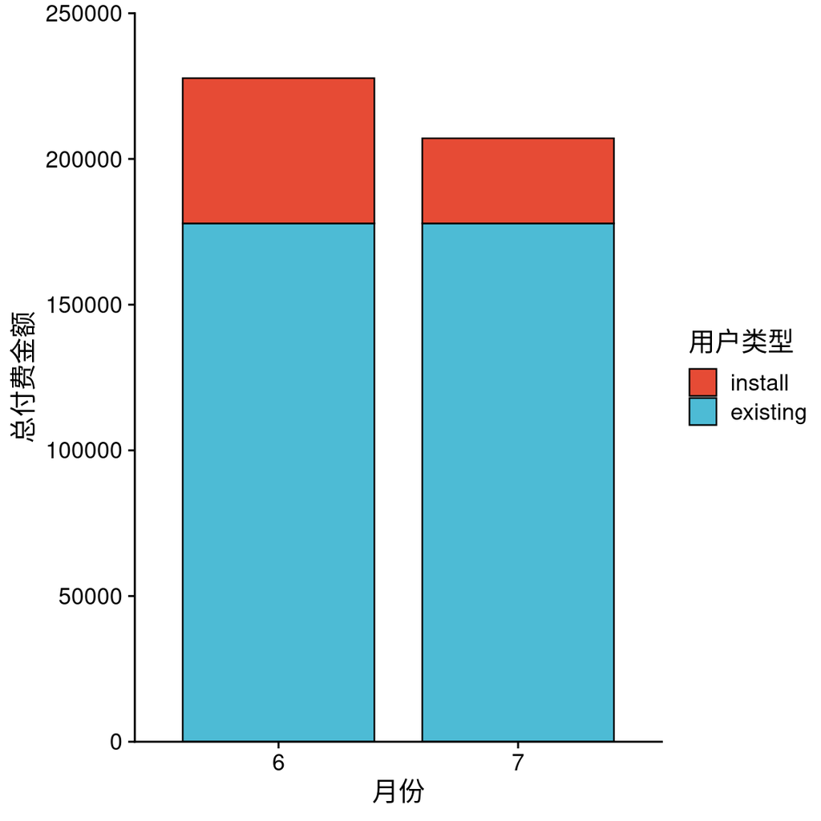

每月充值情况

```r
ggplot(mau_payment_summary, aes(x = factor(log_month), y = total_payment)) +
  geom_col(aes(fill = usser_type),
           color = 'black',
           size = 0.4, # 描边粗细
           width = 0.8) + # 柱子宽度
  scale_y_continuous(limits = c(0,250000), # y轴标度范围
                     expand = c(0,0)) + # 色条从x轴起始
  scale_fill_npg() +
  theme_half_open() +
  labs(x = '月份', y = '总付费金额', fill = '用户类型')
```

**新用户付费金额直方图：**

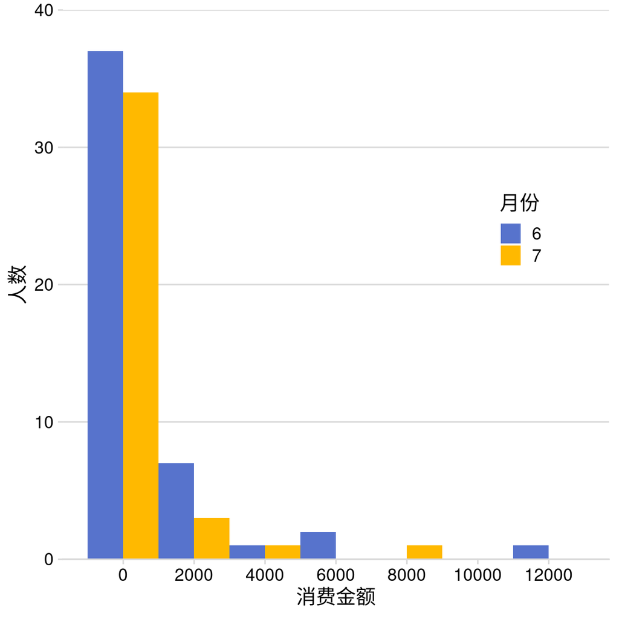

新用户付费金额直方图

```r
mau_payment %>%
  filter(usser_type == 'install', sum_payment != 0) %>%
  ggplot(aes(x = sum_payment, fill = factor(log_month))) +
    geom_histogram(position = "dodge", # 直方图的样式， 默认 stack 堆叠图 fill 填充图 dodge 并排图
                 binwidth = 2000) + # 切分窗口
  scale_y_continuous(limits = c(0,40), # y轴标度范围
                     expand = c(0,0)) + # 色条从x轴起始
   scale_x_continuous(
     breaks = seq(0, 12000, 2000)) + # 以150为单位划分y轴
  scale_fill_manual(values = c('#5773CC', '#FFB900')) + # 手动给颜色
  theme_minimal_hgrid() +
  labs(x = '消费金额', y = '人数', fill = '月份') +
  theme(legend.position = c(.8,.6)) # 调整图例位置
```

**每个月的新老用户人数比例：**

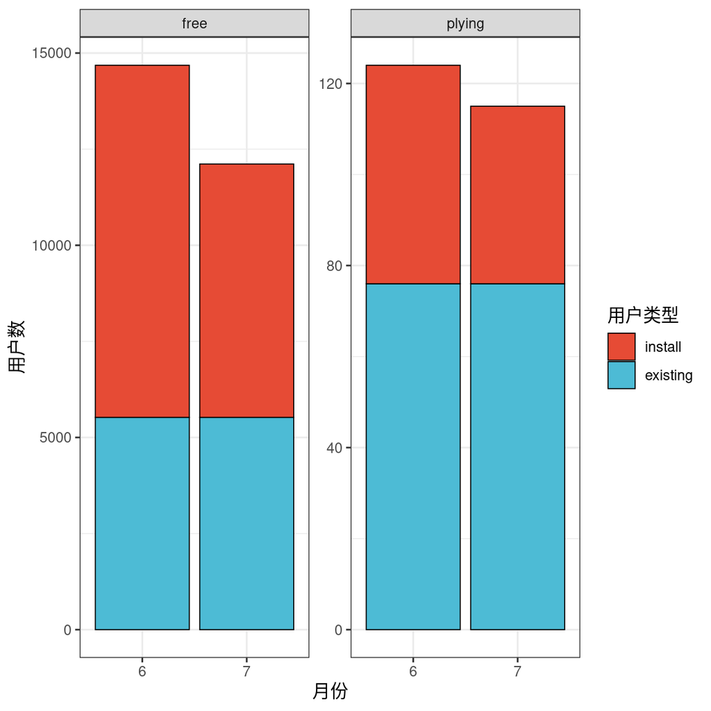

新老用户的比例

```r
# 区分一下新老用户
baipiao2 = group_by(mau_payment, log_month, usser_type, baipiao) %>%
  summarise(count = n()) %>%
  mutate(usser_type = factor(usser_type, levels = c('install', 'existing'))) # factor调整usser_type列的levels顺序,让install在堆叠图中位于上方

ggplot(baipiao2, aes(x = factor(log_month), y = count, fill = usser_type)) +
  geom_col(color = 'black',
           size = 0.3) +
  facet_wrap(~baipiao, scales = 'free') +
  scale_fill_npg() +
  labs(x = '月份', y = '用户数', fill = '用户类型') +
  theme_bw()
```

通过观察销售额数据的构成，可以发现新用户带来的销售额减少了，其中消费额在 2000 日元以下的轻度消费用户的人数减少所造成的影响最大，并且免费用户数量在本月也出现明显下降。

## 1.5 解决对策

**问题：**游戏的销售额相比上月减少了

**现象：**新用户数量减少导致小额消费用户数量减少，进而导致销售额减少

**原因：**本月的商业宣传活动相比上月减少了

**对策：**再次开展商业宣传活动并恢复到之前的水平

# 案例二：社交游戏用户流失分析

## 2.1 现状和预期

《黑猫拼图》从这个月开始，用户数开始大量减少。因为这款游戏是公司具有代表性的成功应用，所以这次用户数减少的问题也备受关注。 因此，社交游戏事业部的部长向数据分析部门下达了指示：“调查清楚用户数量减少的原因，并尽全力改善这种状况。”

## 2.2 寻找问题

我们可以尝试做出如下假设：

1. 商业推广上存在问题，流失的用户数超过了新增的用户数
2. 每月不同主题的游戏活动开始变得很无聊，用户都不爱玩了
3. 按用户的性别或者年龄段等属性来划分用户群，可能是其中某个用户群出现了问题

通过咨询市场部和游戏开发部，得到了下述信息：

1. 同上月相比，商业推广的力度大体没变，新增用户数也大致保持在相同的水平
2. 开展的各种游戏活动同上月相比几乎没有变化

因此，只剩下第 3 条假设”可能是其中某个用户群出现了问题”需要验证了。

## 2.3 数据收集

整理一下分析的过程：

1.《黑猫拼图》游戏的用户数量相比上月减少了 （事实） 2. 某些用户群的用户数量减少了 （假设） 3. 针对该用户群制定相应的措施，使用户数量回到和上月相同的水平 （解决方案）

为了能够通过数据明确问题，我们需要以下数据：

- DAU （Daily ActiveUser，每天至少来访 1 次的用户数据）
- user_info（用户画像数据）

## 2.4 数据分析

### 2.4.1 导入数据

```r
redau = read_csv('./R/section4-dau.csv') # dau
user_info = read_csv('./R/section4-user_info.csv') # 用户画像
```

### 2.4.2 数据清洗

**双表关联:**

```r
dau_user_info = left_join(redau, user_info, by =c('user_id', 'app_name')) %>%
  mutate(log_month =str_sub(log_date, 1, 7)) # 增加登录月份列

summary(dau_user_info)

dau_user_info %>%
  head() %>%
  datatable()
```

```
    log_date            app_name            user_id       install_date
 Min.   :2013-08-01   Length:170360      Min.   :    1   Min.   :2013-04-15
 1st Qu.:2013-08-14   Class :character   1st Qu.:14349   1st Qu.:2013-06-03
 Median :2013-08-28   Mode  :character   Median :28976   Median :2013-07-17
 Mean   :2013-08-29                      Mean   :26162   Mean   :2013-07-09
 3rd Qu.:2013-09-12                      3rd Qu.:37611   3rd Qu.:2013-08-13
 Max.   :2013-09-30                      Max.   :49525   Max.   :2013-09-30
    gender            generation    device_type         log_month
 Length:170360      Min.   :10.00   Length:170360      Length:170360
 Class :character   1st Qu.:20.00   Class :character   Class :character
 Mode  :character   Median :20.00   Mode  :character   Mode  :character
                    Mean   :24.39
                    3rd Qu.:30.00
                    Max.   :50.00
```

|  | log_date | app_name | user_id | install_date | gender | generation | device_type | log_month |
| --- | --- | --- | --- | --- | --- | --- | --- | --- |
| 1 | 2013-08-01 | game-01 | 33754 | 2013-08-01 | M | 20 | iOS | 2013-08 |
| 2 | 2013-08-01 | game-01 | 28598 | 2013-07-16 | M | 50 | iOS | 2013-08 |
| 3 | 2013-08-01 | game-01 | 30306 | 2013-07-20 | F | 30 | iOS | 2013-08 |
| 4 | 2013-08-01 | game-01 | 117 | 2013-04-17 | F | 20 | iOS | 2013-08 |
| 5 | 2013-08-01 | game-01 | 6605 | 2013-05-02 | M | 20 | iOS | 2013-08 |
| 6 | 2013-08-01 | game-01 | 346 | 2013-04-18 | F | 30 | iOS | 2013-08 |

**按性别分类用户:**

|  | 月份 | 女 | 男 |
| --- | --- | --- | --- |
| 1 | 2013-08 | 47343 | 46842 |
| 2 | 2013-09 | 38027 | 38148 |

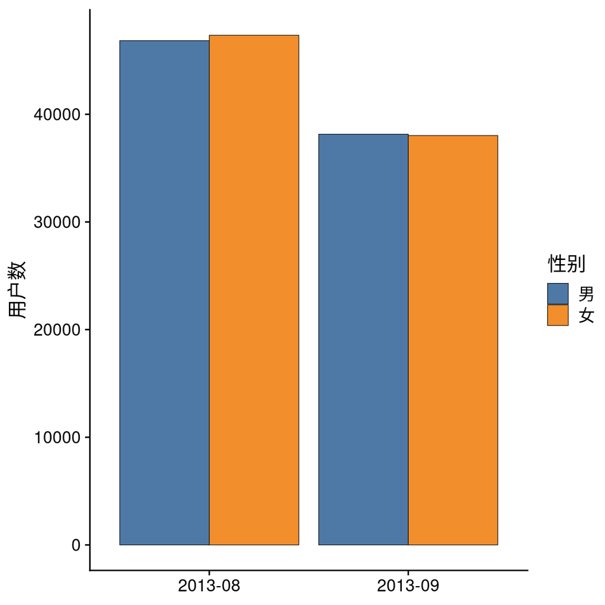

```r
gender_tb = select(dau_user_info, log_month, gender) %>%
  mutate(log_month = factor(log_month)) %>%
  group_by(log_month, gender) %>%
  summarise(conut = n()) %>%
  mutate(gender = recode(gender, 'F' = '女', 'M' = '男'))

# table(dau_user_info[, c("log_month", "gender")])

gender_tb %>%
  pivot_wider(names_from = gender, values_from = conut) %>%
  rename(月份 = log_month) %>%
  datatable()

gender_tb %>%
  ggplot(aes(x = log_month, y = conut, fill = gender)) +
  geom_col(position = "dodge",
           color = 'black',
           size = 0.2) +
  scale_fill_tableau() +
  theme_half_open() +
  labs(x = NULL, y = '用户数', fill = '性别')
```

可以看到虽然整体上用户数量在下降，但用户的男女构成比例大体没有变化。由此可以判断性别对用户数量下降的影响很小。

**按年龄段分类用户：**

|  | 月份 | 10-19岁 | 20-29岁 | 30-39岁 | 40-49岁 | 50-59岁 |
| --- | --- | --- | --- | --- | --- | --- |
| 1 | 2013-08 | 18785 | 33671 | 28072 | 8828 | 4829 |
| 2 | 2013-09 | 15391 | 27229 | 22226 | 7494 | 3835 |

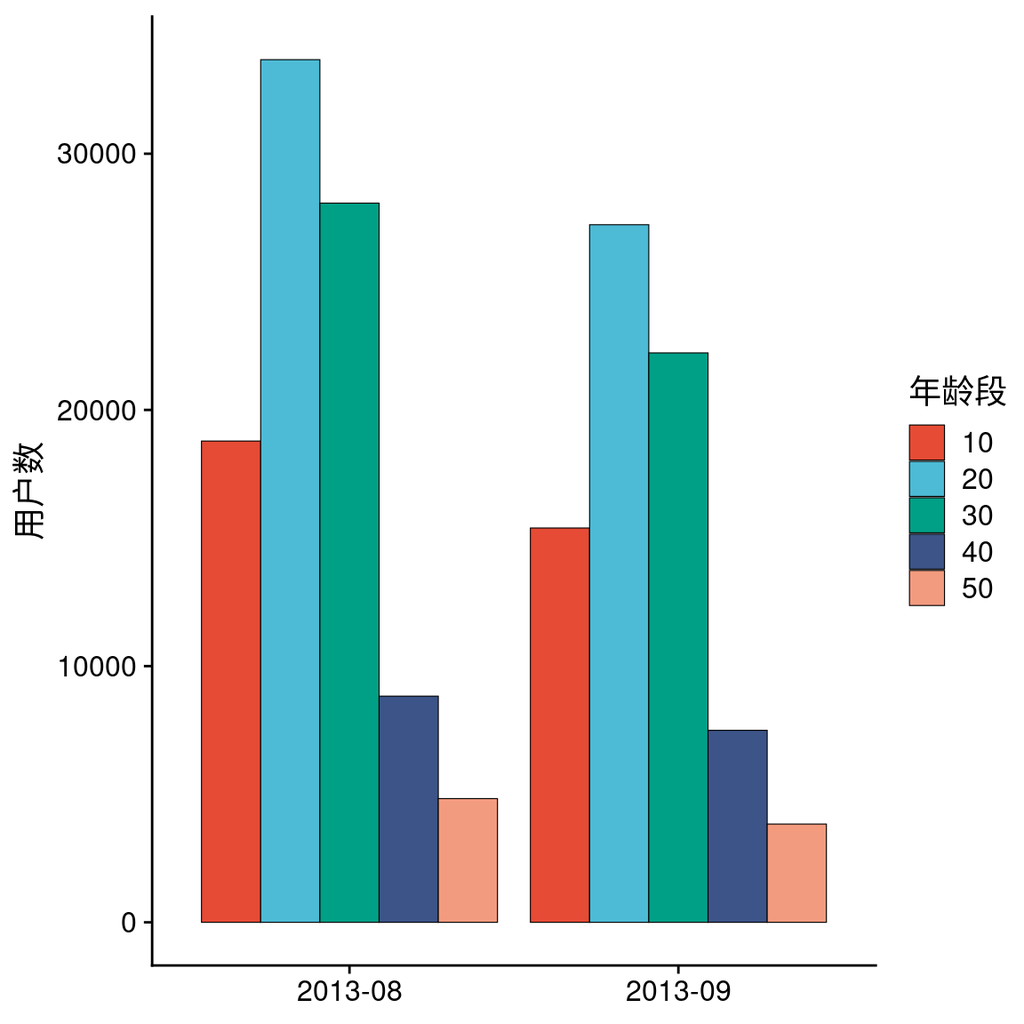

```r
group_by(dau_user_info, log_month, generation) %>%
summarise(conut = n()) %>%
  mutate(generation = generation) %>%
  mutate(generation = recode(generation,
                             '10' = '10-19岁', '20' = '20-29岁',
                             '30' = '30-39岁', '40' = '40-49岁',
                             '50' = '50-59岁')) %>%
  pivot_wider(names_from = generation, values_from = conut) %>%
  rename(月份 = log_month) %>%
  datatable()

  # group_by(dau_user_info, log_month, generation) %>%
  # summarise(conut = n()) %>%
  #   mutate(generation = factor(generation)) %>%
  #   ggplot(aes(x = log_month, y = conut, fill = generation)) +
  #   geom_col(position = 'dodge') +
  #   scale_fill_npg() +
  #   theme_half_open()

# 直接出图的话可以更简单 geom_bar
mutate(dau_user_info, generation = factor(generation)) %>%
  ggplot(aes(x = factor(log_month), fill = generation)) +
  geom_bar(position = 'dodge',
           color = 'black', size = 0.2) +
  scale_fill_npg() +
  theme_half_open() +
  labs(x = NULL, y = '用户数', fill = '年龄段')
```

可以看到所有年龄段的用户数都在下降，虽然20-39这个年龄段下降的多一点，但在整体用户数量中所占的比例没有发生大的变化。 因此需要再进一步细分，看看是否某个性别下的某个年龄段的用户数量减少了。

**按 性别&年龄 分类用户:**

|  | log_month | F_10 | F_20 | F_30 | F_40 | F_50 | M_10 | M_20 | M_30 | M_40 | M_50 |
| --- | --- | --- | --- | --- | --- | --- | --- | --- | --- | --- | --- |
| 1 | 2013-08 | 9091 | 17181 | 14217 | 4597 | 2257 | 9694 | 16490 | 13855 | 4231 | 2572 |
| 2 | 2013-09 | 7316 | 13616 | 11458 | 3856 | 1781 | 8075 | 13613 | 10768 | 3638 | 2054 |

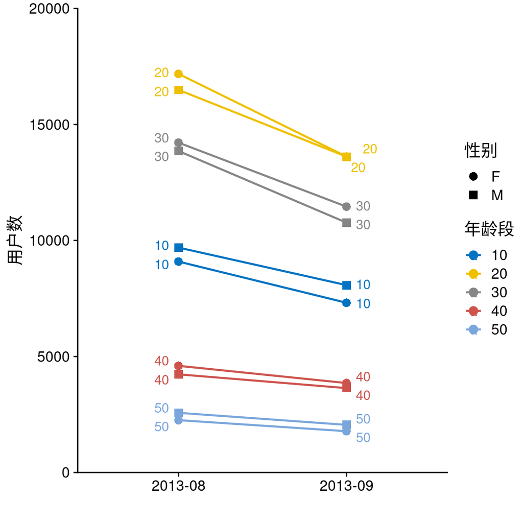

```r
group_by(dau_user_info, log_month, gender, generation) %>%
  summarise(count = n()) %>%
  pivot_wider( # 长表变宽表，有多个列名列或者多个列值列时用c()即可
    names_from = c(gender, generation), # 指定两个要变成列名的列
    values_from = count) %>% # 指定数值列
datatable()

# 配对折线图
tmp = group_by(dau_user_info, log_month, gender, generation) %>%
      summarise(count = n()) %>%
      mutate(generation = factor(generation))

ggplot(tmp, aes(x = log_month, y = count, color = generation)) +
  # 点
  geom_point(aes(shape = gender), size = 3) + # 设置点
  scale_shape_manual(values = c(16,15)) + # 设置点的形状 也可写为 21:22 level 可以调整圈的大小
  # 点加标签
  ##  geom_text 的标签不好看，会被挡住
  ##geom_text(aes(label = str_remove(Triplet,'Triplet '))) +
  ## ggrepel 加点
  geom_text_repel(data = filter(tmp, log_month == '2013-08'), # # 先给组a加点
                  aes(label = generation),
                  nudge_x = -0.1, # 调整标签位置
                  min.segment.length = Inf # 最小连线距离为无穷大，即永不连线
  ) +
  geom_text_repel(data = filter(tmp, log_month == '2013-09'), # # 先给组a加点
                  aes(label = generation),
                  nudge_x = 0.1, # 调整标签位置
                  min.segment.length = Inf # 最小连线距离为无穷大，即永不连线
  ) +

  # 折线
  geom_line(aes(group = interaction(generation, gender)), # 对折线进行分组，按照年龄和性别
            size = 0.8) +
  # 修改y轴标度 continuous 连续型
  scale_y_continuous(
    expand = c(0,0), # 设置原点
    limits = c(0,20000) # 设置幅度
  ) +
  # 修改yx轴标题
  labs(x = "", y= "用户数", color = '年龄段', shape = '性别') +
  scale_color_jco() +
  theme_half_open()
```

通过将性别和年龄段进行交叉组合，同样发现各用户群的用户数量整体都下降了，但每个用户群所占的比例大体没变，也没有发现哪个用户群的数量急剧下降。

下面我们需要考虑的是用户所使用的设备的差异。

**按登陆设备分类用户：**

|  | 用户设备 | 2013-08 | 2013-09 |
| --- | --- | --- | --- |
| 1 | Android | 46974 | 29647 |
| 2 | iOS | 47211 | 46528 |

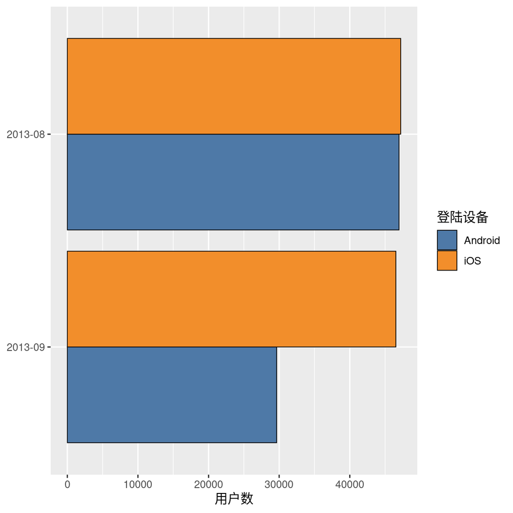

```r
group_by(dau_user_info, log_month, device_type) %>%
  summarise(count = n()) %>%
  pivot_wider(names_from = log_month, values_from = count) %>%
  rename(用户设备 = device_type) %>%
  datatable()

  # 绘图
  group_by(dau_user_info, log_month, device_type) %>%
    summarise(count = n()) %>%
    pivot_wider(names_from = log_month, values_from = count) %>%
    pivot_longer( # 宽变长
                 -device_type, # device_type 列不动 或者!device_type
                 names_to = 'log_month', values_to = 'count') %>%
    ggplot(aes(x = factor(log_month, levels = c('2013-09', '2013-08')), y = count, fill = device_type)) +
    geom_col(position = 'dodge',
             color = 'black', size = 0.3) +
    scale_fill_tableau() +
    labs(x = NULL, y = '用户数', fill = '登陆设备') +
    coord_flip() # xy轴互换
```

可以看到使用 iOS 设备的用户数略有下降，而使用Android的用户却大量减少了，因此这个用户群的分析很可能就是解决该问题的关键。

**用户日活的时间序列分析：**

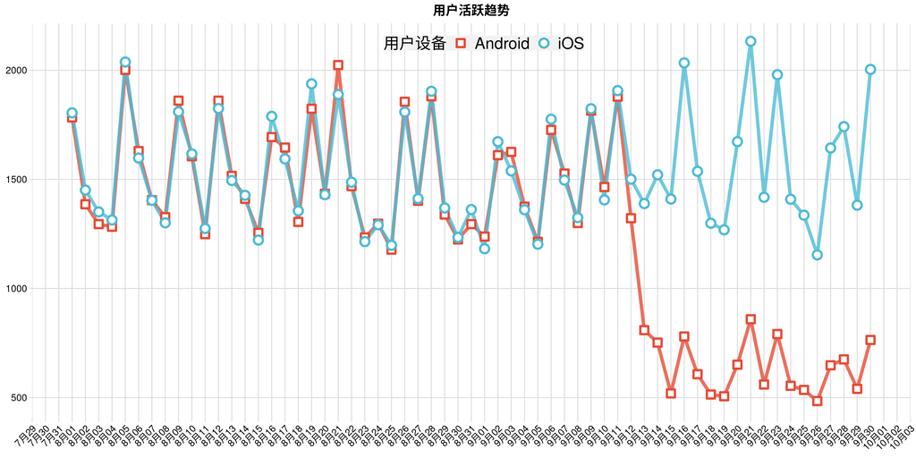

```r
group_by(dau_user_info, log_date, device_type) %>%
    summarise(count = n()) %>%
    ggplot(aes(x = log_date, y = count, color = device_type, shape=device_type)) +
    geom_line(size = 2, alpha = 0.8) +
    geom_point(#shape = 21,
               size = 4,
               stroke = 2, # 描边粗细
               fill = 'white') +
    scale_shape_manual(values = c(22,21)) +
    scale_color_npg() +
    theme_minimal_grid() +
    scale_x_date(date_labels="%b%d",date_breaks  ="1 day") + # %b 月份 %d 天 %y 年  1 day 按天分割
    # 下面的在 theme assistant 调整即可
    theme(axis.text.x = element_text(angle = 45, # 旋转
                                     hjust = 1, # label和坐标点的对齐方式，0 左对齐 0.5 中间对齐 1 右对齐
                                     vjust = 1), # label上下位移
          plot.title = element_text(hjust = 0.5), # 表头居中
          legend.direction = "horizontal", # 调整图例方向 横 horizontal  竖vertical
          legend.position = c(0.4, 0.95), # 调整图例位置
          legend.background = element_rect(fill = "gray95"), # 调整图例背景 灰色
          legend.text = element_text(size=20), # 图例文字大小
          legend.title = element_text(size = 20) # 图例标题文字大小
          ) +
    labs(
         title = '用户活跃趋势', # 表头
         #subtitle = 'this is a point plot', # 二级表头
         x = NULL, # x轴
         y = NULL,# y轴
         color = '用户设备', # 图例名
         shape = '用户设备') # 图例名
```

可以看出，iOS 的用户数和之前大体相同，而 Android 的用户数从9月12日开始急剧减少。 和游戏开发部门确认后，得知9月12日Android版应用进行了一次版本升级。旧版本的Android系统升级应用后，用户就无法登录游戏了。

## 2.5 解决对策

**问题：**《黑猫拼图》游戏的用户数量相比上月减少了

**现象：**使用 Android 手机的用户群数量显著减少了

**原因：**Android 手机端新版本bug

**对策：**紧急修复Android系统中游戏新版本bug

# 案例三：广告投放的A/B测试

## 3.1 现状和预期

公司每月都会开展游戏装备的促销活动，但和其他应用的促销活动相比，《黑猫拼图》的游戏装备促销活动的购买率偏低。因此，我们希望能够通过数据分析找出购买率偏低的原因，改善这种状况。

促销活动广告的购买率比较（《黑猫拼图》/ 公司其他应用）

| 应用名称 | 购买率 |
| --- | --- |
| 《黑猫拼图》 | 6% |
| 应用 A | 12% |
| 应用 B | 12% |

## 3.2 寻找问题

首先，为了明确现状和预期之间的差距，我们思考《黑猫拼图》游戏和其他应用有何不同：

1. 游戏装备促销活动的内容有问题
   - 销售的游戏装备并不是用户需要的
   - 促销打折的力度不够，对用户没有太大吸引力
2. 广告的外观展示有问题

首先针对第 1 个假设，我们咨询了《黑猫拼图》游戏的策划部门，并从那里得到了如下反馈：

- 游戏装备促销活动中出售的游戏装备或许能够用得上
- 和其他应用一样，促销时的游戏装备打五折，这从用户的立场来看是很划算的

之后，我们统计了在促销期间出售的游戏装备的使用情况，发现这些装备是当时最常被使用的装备，用户对这些装备是有需求的。也就是说，上述第 1 个假设中的问题基本不大。

我们再来考虑第2个假设。为了获得和第2个假设相关的信息，我们咨询了负责《黑猫拼图》游戏市场营销的部门，并从那里得到了如下反馈：

- 游戏装备大促销的广告都是由各个应用的设计师负责的，所以广告的质量也是参差不齐
- 《黑猫拼图》游戏的广告的点击率一直比较低（参考下表）

这次的问题恐怕就是第 2 个假设造成的。因此，这次我们将**提升广告的点击率**作为课题来进行数据分析。

促销活动广告的点击率比较（《黑猫拼图》 / 公司其他应用）

| 应用名称 | 点击率 |
| --- | --- |
| 《黑猫拼图》 | 6% |
| 应用 A | 12% |
| 应用 B | 12% |

## 3.3 数据收集

我们来总结一下本案例的问题和解决方案：

**问题：**

- 《黑猫拼图》游戏的广告点击率比其他应用低（事实）
- 《黑猫拼图》游戏的广告设计有问题（假设）

**解决方案：**

- 用点击率高的广告替换目前所使用的广告（解决方案）

为了完成上述方案，需要找到哪种广告更容易被点击。但是，在《黑猫拼图》游戏中，之前每月开展的”游戏装备大促销”活动的广告一直都没有变更过，因此我们缺少可供分析的数据。于是，我们准备了两个不同的广告，通过收集数据来比较哪个广告更容易被用户点击。

**最终获得A/B测试的日志输出：**

- ab_test_imp（关于广告曝光次数的信息）
- ab_test_goal（关于广告点击次数的信息）

## 3.4 数据分析

### 3.4.1 导入数据

```r
## 广告曝光次数
ab_test_imp = read_csv('./R/section5-ab_test_imp.csv')
## 广告点击次数
ab_test_goal = read_csv('./R/section5-ab_test_goal.csv')
```

### 3.4.2 数据清洗

**将曝光表和点击表通过事务id关联在一起：**

```r
ab_test_imp = left_join(ab_test_imp, ab_test_goal,
                        by = 'transaction_id',
                        suffix = c('', '.g')) %>% # 有重名列时给重名列加不同的后缀
  mutate(is_goal = if_else(is.na(user_id.g), 0, 1)) # 判断用户是否点击

head(ab_test_imp) %>%
  datatable()
```

|  | log_date | app_name | test_name | test_case | user_id | transaction_id | log_date.g | app_name.g | test_name.g | test_case.g | user_id.g | is_goal |
| --- | --- | --- | --- | --- | --- | --- | --- | --- | --- | --- | --- | --- |
| 1 | 2013-10-01 | game-01 | sales_test | B | 36703 | 25622 |  |  |  |  |  | 0 |
| 2 | 2013-10-01 | game-01 | sales_test | A | 44339 | 25623 |  |  |  |  |  | 0 |
| 3 | 2013-10-01 | game-01 | sales_test | B | 32087 | 25624 |  |  |  |  |  | 0 |
| 4 | 2013-10-01 | game-01 | sales_test | B | 10160 | 25625 |  |  |  |  |  | 0 |
| 5 | 2013-10-01 | game-01 | sales_test | B | 46113 | 25626 |  |  |  |  |  | 0 |
| 6 | 2013-10-01 | game-01 | sales_test | A | 6605 | 25627 |  |  |  |  |  | 0 |

**计算两种广告的点击率：**

```r
ab_test_imp_cvr_avg = group_by(ab_test_imp, test_case) %>%
  summarise(cvr = sum(is_goal)/n())

ab_test_imp_cvr_avg %>%
  mutate(cvr = str_c(round(cvr*10,2),'%')) %>%
  rename(广告方案 = test_case, 点击率 = cvr) %>%
  datatable()
```

[output not shown]

**进行卡方检验:**

```r
chisq.test(ab_test_imp$test_case, ab_test_imp$is_goal)
```

```
    Pearson's Chi-squared test with Yates' continuity correction

data:  ab_test_imp$test_case and ab_test_imp$is_goal
X-squared = 308.38, df = 1, p-value < 0.00000000000000022
```

可以看到两种广告方案的点击率是存在显著性差异的。

**广告 A 和 B 点击率的时间序列变化：**

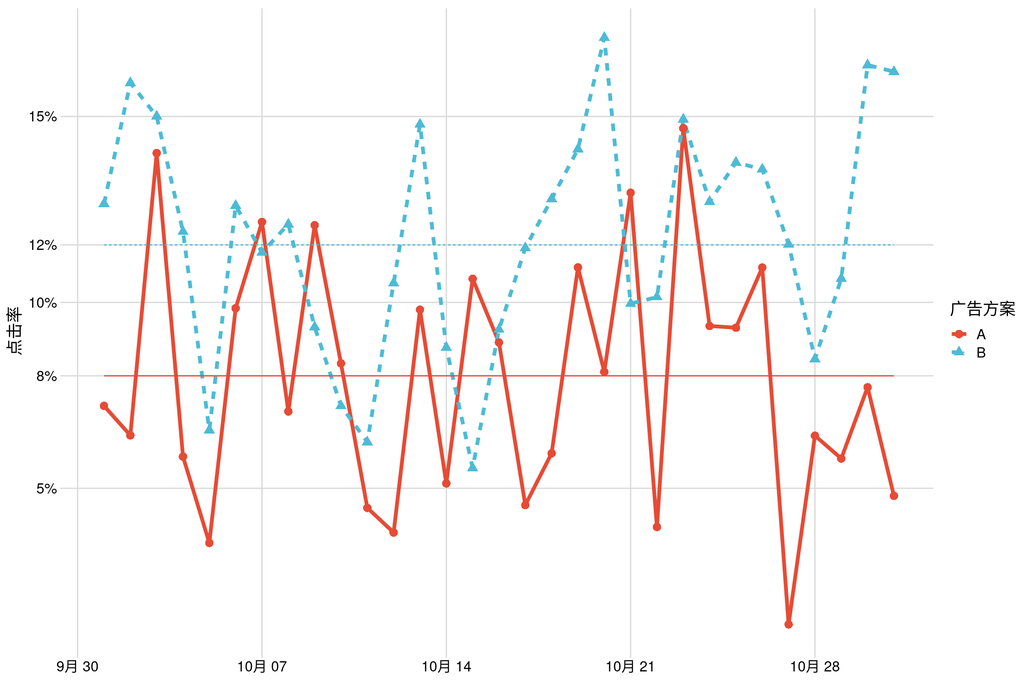

```r
# 计算不同广告每天的点击率和总点击率
ab_test_imp_summary = group_by(ab_test_imp, log_date, test_case) %>%
  summarise(
    imp = n(), # 每日曝光数
    cv = sum(is_goal), # 每日点击数
    cvr = cv/imp # 每日点击率
  ) %>%
  group_by(test_case) %>%
  mutate(cvr_avg = sum(cv)/sum(imp)) # 总点击率

# 点击率时序图
ggplot(ab_test_imp_summary, aes(x = log_date, y = cvr,
                                shape = test_case,
                                color = test_case,
                                linetype = test_case)) + # 线型
  geom_line(size = 1.5) +
  geom_point(size = 3) +
  geom_line(aes(y = cvr_avg, color = test_case)) +
  scale_y_continuous(breaks = c(0.05,
                                ab_test_imp_cvr_avg[1,2] %>%pull(),
                                0.10,
                                ab_test_imp_cvr_avg[2,2] %>% pull(),
                                0.15),
                     labels = str_c(
                                    c(0.05,
                                      ab_test_imp_cvr_avg[1,2] %>%
                                        pull() %>% round(digits = 2),
                                      0.10,
                                      ab_test_imp_cvr_avg[2,2] %>%
                                        pull() %>% round(digits = 2),
                                      0.15) * 100,
                                    '%')

                     ) + # 标出平均数的值
  scale_color_npg() +
  theme_minimal_grid() +
  labs(x = NULL, y = '点击率', color = '广告方案',
       shape = '广告方案', linetype = '广告方案')
```

## 3.5 解决对策

**问题：**《黑猫拼图》游戏的促销活动的购买率偏低 **原因：**游戏的广告设计有问题 **对策：**用点击率高的广告方案替换目前所使用的广告

# 案例四：如何通过多种广告组合获得更多的用户

## 4.1 现状和预期

在互联网上投放广告，单价比较便宜，并且能够吸引到稳定的新注册用户。虽然互联网广告可以根据投入的成本预估效果，但相对于电视、杂志等传统媒体来说，它的受众数量是有限的，因此要想使用户达到一定数量，一般还是要在传统媒体上投放广告。然而，和互联网广告相比，传统媒体的广告成本要高得多。另外，如下图所示，根据广告投放媒体的属性不同，广告效果 CPI（Cost Per Install，获得一个新用户所需的成本）的变动也很大。

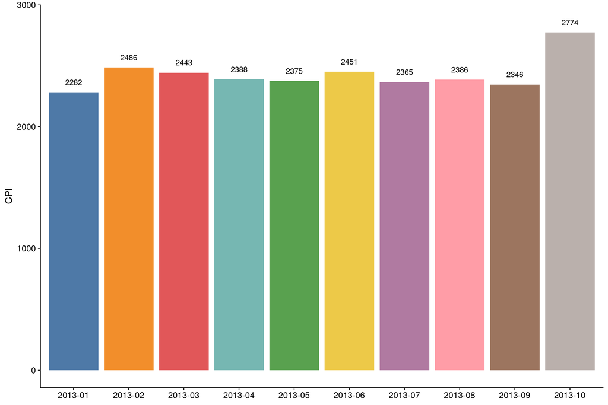

广告效果(CPI)

## 4.2 寻找问题

如上图所示，传统媒体广告的月平均CPI 在 2282 日元到 2774 日元之间波动。如果仅仅是看数值，可能会觉得月平均 CPI 的差距并不大。但由于每获得一个用户的成本都很高，因此我们要尽可能地缩小这 500 日元的差距，如果可能的话，应尽量确保 CPI 保持在 2282 日元左右。

我们将本例中的问题细化如下：

**在传统媒体上的广告投放分配比例存在问题**

**→ 每月在电视和杂志上投放广告的比例有所不同**

通过和广告部确认，我们了解到，虽然我们无法指定投放广告的电视或杂志媒体数量，但我们可以告诉广告公司分别投放在电视和杂志上的比率，因此我们需要：

1. 基于过去的数据，明确在电视和杂志上投放广告的广告费和各自所获得的用户数之间的关系
2. 基于上述关系，确定以何种比例在电视和杂志上投放广告

我们可以建立一个线性回归模型来解决这个问题： 新用户数 = a*电视广告 + b*杂志广告 + c

## 4.3 数据收集

从市场部获得《黑猫拼图》游戏在电视和杂志上投入的广告费和所获得的新用户数

## 4.4 数据分析

### 4.4.1 导入数据

```r
# 导入数据并清洗
ad_data = read_csv('R/ad_result.csv') %>%
  pivot_longer(-c(month, install),
               names_to = '广告平台',
               values_to = '投入费用') %>% # 宽表变长表
  select(广告平台, 投入费用, install) %>%
  mutate(广告平台 = recode(广告平台, 'tvcm' = '电视广告', 'magazine' = '杂志广告'))
# 月份删掉也可以，跟本次分析没关系
```

### 4.4.2 分析数据

为了确认投入费用与获得新用户数是否存在线性关系，需要绘制广告费和新用户数的散点图:

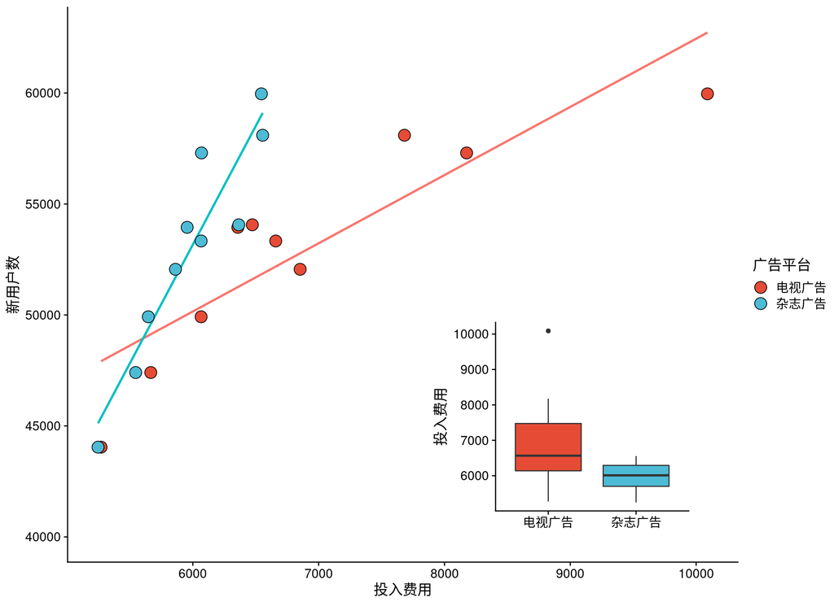

```r
## 散点图
point1 = ggplot(ad_data, aes(x = 投入费用, y = install, fill = 广告平台)) +
    geom_smooth(method = 'lm', # 使用直线回归模型
              aes(color = 广告平台),
              se = F) +
  geom_point(shape = 21, size = 5) +

  labs(y = '新用户数') +
  scale_fill_npg() +
  theme_half_open()

## 箱线图
box1 = ggplot(ad_data, aes(x = 广告平台, y = 投入费用)) +
  geom_boxplot(aes(fill = 广告平台)) +
  scale_fill_npg() +
  theme_half_open() +
  labs(x = NULL) +
  theme(legend.position = "none")

# 绘制图中图
plot_pos = tibble(x = 10000, y = 40000, plot = list(box1))
point1 + geom_plot(data = plot_pos, aes(x = x, y = y, label = plot))

# ggplot(ad_data, aes(x = 投入费用, y = install, fill = 广告平台)) +
#   geom_point(shape = 21) +
#   geom_smooth(method = 'gam', se = F) +
#   geom_smooth(method = 'lm', aes(color = 广告平台), se = F) +
#   facet_wrap(~广告平台) +
#   theme_bw() +
#   theme(legend.position = 'none') # 不要图例
```

无论是电视广告还是杂志广告，从散点图来看，随着投入的广告费用的增加，新获得的用户数也会增加，反应在图上就是数据点不断地向右上方延伸。既然明确了广告费和新用户数之间存在关系，下面我们就来着手进行回归分析。

**线性回归：**

```
Call:
stats::lm(formula = f, data = d)

Residuals:
     Min       1Q   Median       3Q      Max
-1406.87  -984.49   -12.11   432.82  1985.84

Coefficients:
             Estimate Std. Error t value Pr(>|t|)
(Intercept)  188.1743  7719.1308   0.024  0.98123
tvcm           1.3609     0.5174   2.630  0.03390 *
magazine       7.2498     1.6926   4.283  0.00364 **
---
Signif. codes:  0 '***' 0.001 '**' 0.01 '*' 0.05 '.' 0.1 ' ' 1

Residual standard error: 1387 on 7 degrees of freedom
Multiple R-squared:  0.9379,    Adjusted R-squared:  0.9202
F-statistic: 52.86 on 2 and 7 DF,  p-value: 0.00005967
```

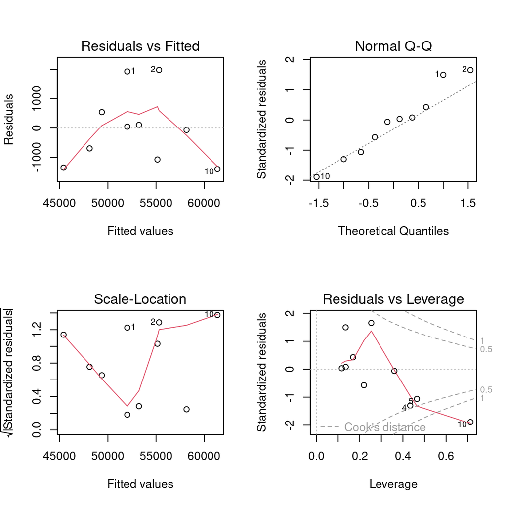

```r
# 处理数据
regr_data = ad_data %>%
  pivot_wider(names_from = 广告平台, values_from = 投入费用) %>%
  rename('tvcm' = '电视广告', 'magazine' = '杂志广告')
# 定义任务
regr_task = makeRegrTask(data = regr_data, target = 'install')
# 定义学习器
lin = makeLearner('regr.lm')
# 训练模型
lin_model = train(lin,regr_task)
# 理解模型
lin_model_data = getLearnerModel(lin_model)
# 详细数据
summary(lin_model_data)
# 模型诊断图
par(mfrow = c(2, 2))
plot(lin_model_data)
par(mfrow = c(1, 1))
```

得到的线性回归方程为： 新用户数 = 1.361*电视广告 + 7.250*杂志广告 + 188.174

通过观察残差的分布，我们发现 1Q（第 1 四分位数）的绝对值比3Q（第 3 四分位数）的绝对值要大，这表明某些数据的分布偏差过大。但由于自由度校正判定系数的值高达 0.92，因此之前所决定的广告策略应该没有什么问题。 因此广告投放策略可以调整为电视广告进行最低投入维持关系，其余投入杂志广告。

**尝试使用广义加性模型进行非线性回归：**

```
     Model-based Boosting

Call:
mboost::gamboost(formula = f, data = data, family = family, control = ctrl)


     Squared Error (Regression)

Loss function: (y - f)^2


Number of boosting iterations: mstop = 100
Step size:  0.1
Offset:  53013
Number of baselearners:  2

Selection frequencies:
    bbs(tvcm, df = dfbase) bbs(magazine, df = dfbase)
                      0.82                       0.18
```

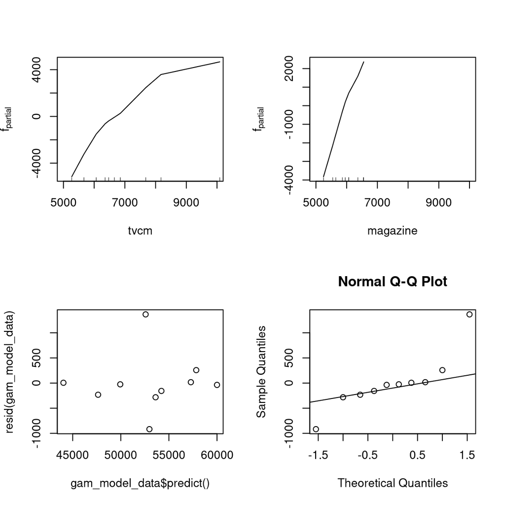

```r
# 定义任务
gam_task = makeRegrTask(data = regr_data, target = 'install')
# 定义学习器
gam = makeLearner('regr.gamboost')
# 训练模型
gam_model = train(gam,gam_task)
# 理解模型
gam_model_data = getLearnerModel(gam_model)
# 详细数据
summary(gam_model_data)


# 绘图
par(mfrow = c(2, 2)) # 分成九宫格

# 每个预测变量对臭氧估计贡献的关系图
plot(gam_model_data, type = "l",xlim = c(5000,10000))
# 下面的边际条代表样本的位置，样本较少的地方可能发生过拟合

# 预测值和残差图 残差、拟合值图 要是一条直线
plot(gam_model_data$predict(),  # 预测值
     resid(gam_model_data)) # 残差
# plot(gam_model_data$fitted(),  # 和上面一模一样 预测值相对于残差图
#      resid(gam_model_data))

# qq 图 理论分为数图
qqnorm(resid(gam_model_data)) # 大多数残差都位于对角线说明近似正态分布
qqline(resid(gam_model_data)) # 尾部有一些偏差是比较常见的
par(mfrow = c(1, 1))
```

从诊断图来看，GAM模型拟合效果要好于LM模型，但结论是一致的，杂志广告的投放收益要远高于电视广告（图一图二的斜率）。

## 4.5 解决对策

本例中我们围绕如下问题进行了分析。

1. 通过各种传统媒体广告所获得的新用户数不尽相同（事实）
2. 每月获得的新用户数与在电视和杂志上的广告投放比例相关（假设）
3. 把握电视广告费和杂志广告费各自与获得的新用户数之间的关系
4. 基于这种关系，确定一个最佳的广告分配比例

从分析结果可以看出，相比于电视广告，杂志广告的效果要更好一些。即便采取只投放杂志广告而不投放电视广告的极端行为，效果也不会太差。但是回归分析尤其是非线性回归对训练集范围外的数值预测可能会很差，因此对超出本训练集的数值进行预测时要谨慎。

但为了维持和广告公司的良好合作关系，经过讨论，我们将按照下述比例来分配广告费用：

- 电视广告：4200 万日元
- 杂志广告：7500 万日元

使用模型预测新用户数：

- lm模型：

```r
new_data = tibble(tvcm = 4200, magazine = 7500)
# lm模型：
predict(lin_model, newdata = new_data)
```

```
Prediction: 1 observations
predict.type: response
threshold:
time: 0.00
  response
1 60277.61
```

- GAM模型:

```r
# GAM模型
predict(gam_model, newdata = new_data)
```

```
Prediction: 1 observations
predict.type: response
threshold:
time: 0.00
  response
1 49032.48
```

根据模型的预测，我们预计能获得5到6万新用户。